# 非正定値内積行列で座標化する

ryamada

2018年5月26日

# 何が嬉しい処理なのか？

曲線・曲面上の点間距離が知りたいが、そのためには、「最短経路を割り出し」て、最短経路にそって巻尺を這わせて測定する必要がある。

グラフになっていれば、グラフ上の最短距離を求めるアルゴリズムを回すことがそれに相当する。

いずれにしろ、点の並び具合と、隣り合う点の間の距離を「積分」することが必要。

『普通の平面』ではそんな面倒なことはしなくてよい。

点に座標を与えて、

$$(x_1-x_2)^T (x_1-x_2) = (x_1-x_2)^T I (x_1-x_2)$$

とすれば距離の２乗が求められる。

なぜなら、平面ではいたるところで内積が単位行列 $I$となっているから。

曲線・曲面では場所ごとに内積を定める行列が異なっているので、うまく行かない。

『非正定値内積行列で座標化する』は、$(x_1-x_2)^T M (x_1-x_2)$ によって、いたるところの点同士の距離が座標から直接求められるようにする作戦である。

積分しなくてよいようにする作戦である。

逆に言うと、曲がっているので、積分することが必要な情報だったもの(グラフそのもの)に、自由度を与えて、積分しないで、すべての点間関係(多様体全体の様子)を簡単に取り出せる表現に改めること、そして、そのような表現が持つ特徴を使って、多様体の様子を記述する(比較・分類したりする)作戦である。

やってみよう。

# １次元グラフ

直線状のグラフを考える。

ノード間距離を求めることができる。

距離と内積には内積を定める対称行列Mが与えられると、以下の関係を満足する。

$$(x_1-x_2)^T M (x_1-x_2) = x_1^T M x_1 + x_2^T M X_2 -2 x_1^T M x_2$$

今、距離$(x_1-x_2)^T M (x_1-x_2)$は与えられるが、$x^T M x$は不明である。

ここですべての点で$x^T M x=1$であると仮定した上で、座標を与えることとする。

これにより点間距離さえわかれば、内積行列を定めることができる。

その内積行列$P$を

$$P = X^T S X = V^T \Sigma V = V^T |\Sigma|S V =(V \sqrt{|\Sigma|})^T S (V \sqrt{|\Sigma|})$$

と固有値分解することで、

$X$をグラフの頂点の座標とすることにする。

ただし、$\Sigma$は固有値を対角成分とする行列、 $|\Sigma|$ は固有値の絶対値を対角成分とする行列、 $S$は固有値の具法を対角成分とする行列、 $\sqrt{|\Sigma}$ は固有値の絶対値の平方根を対角成分とする行列とする。

# Rでやってみる

まずは、内積計算の関数を準備する。

```r
my.ip <- function(v1,v2,M){
    matrix(v1,nrow=1) %*% M %*% matrix(v2,ncol=1)
}
my.ip.mat <- function(x,M){
    n <- length(x[,1])
    ret <- matrix(0,n,n)
    for(i in 1:n){
        for(j in 1:n){
            ret[i,j] <- my.ip(x[i,],x[j,],M)
        }
    }
    return(ret)
}
my.D2IP <- function(D,L=rep(1,length(D[,1]))){
  ret <- -D^2
  ret <- ret + L
  ret <- t(t(ret)+L)
  ret <- ret/2
  diag(ret) <- L
  return(ret)
}
my.IPcoords <- function(g,e.len){
  # 距離行列
  D <- distances(g,weights=e.len)
  # 内積行列
  P <- my.D2IP(D)
  # 固有値分解
  eout <- eigen(P)
  # 固有値の符号
  s <- sign(eout[[1]])
  # 内積行列(対角成分が±1)
  M <- diag(s)
  # 固有値絶対値の平方根を対角成分とする行列
  sq.ev <- sqrt(eout[[1]] * s)
  # 頂点座標
  V <- eout[[2]] %*% diag(sq.ev)
  return(list(X=V,M=M,eout=eout,D=D,P=P,s=s))
}
```

## エッジ長がすべて等しい単純な一本鎖グラフ

グラフを作り、エッジ長を与え、 頂点間距離行列を作成し、 内積行列を作る。

```r
# 1次元グラフ
library(igraph)
# 頂点数
n1 <- 100
el1 <- cbind(1:(n1-1),2:n1)
# グラフオブジェクト
g1 <- graph.edgelist(el1,directed=FALSE)
# エッジ長
e.len1 <- rep(1,length(el1[,1]))
```

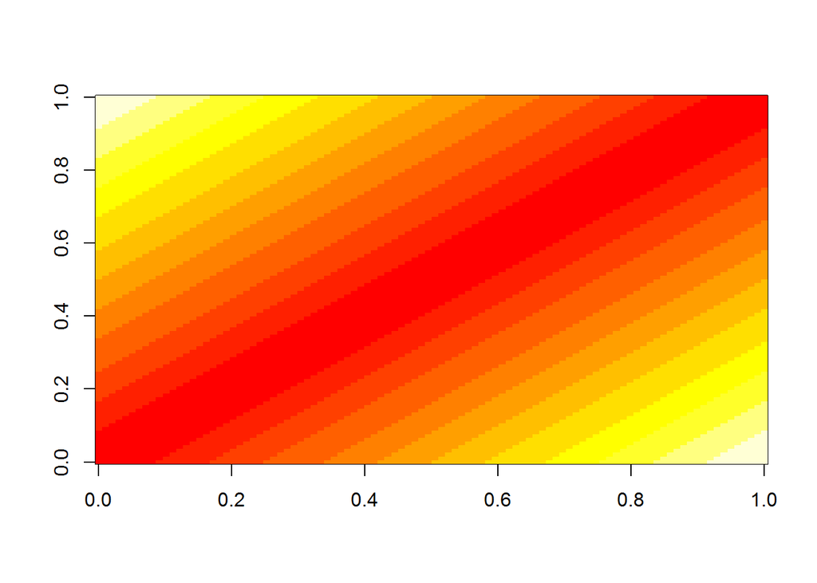

```r
ipout1 <- my.IPcoords(g1,e.len1)
# 距離行列
image(ipout1$D)
```

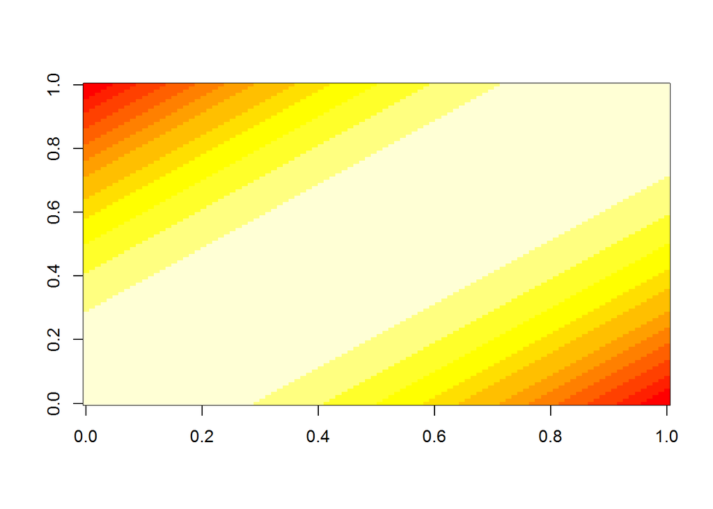

```r
# IP行列
image(ipout1$P)
```

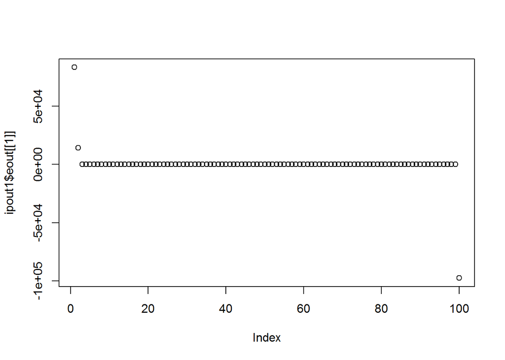

```r
# 固有値
plot(ipout1$eout[[1]])
```

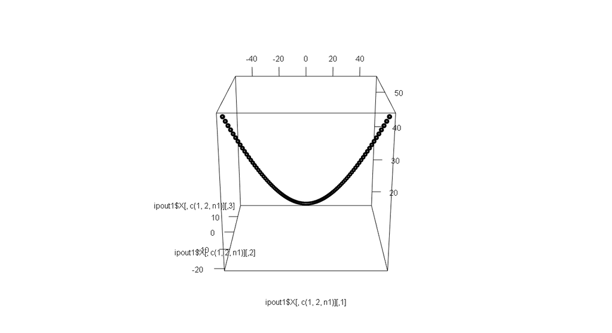

```r
plot3d(ipout1$X[,c(1,2,n1)])
spheres3d(ipout1$X[,c(1,2,n1)],radius=1)
```

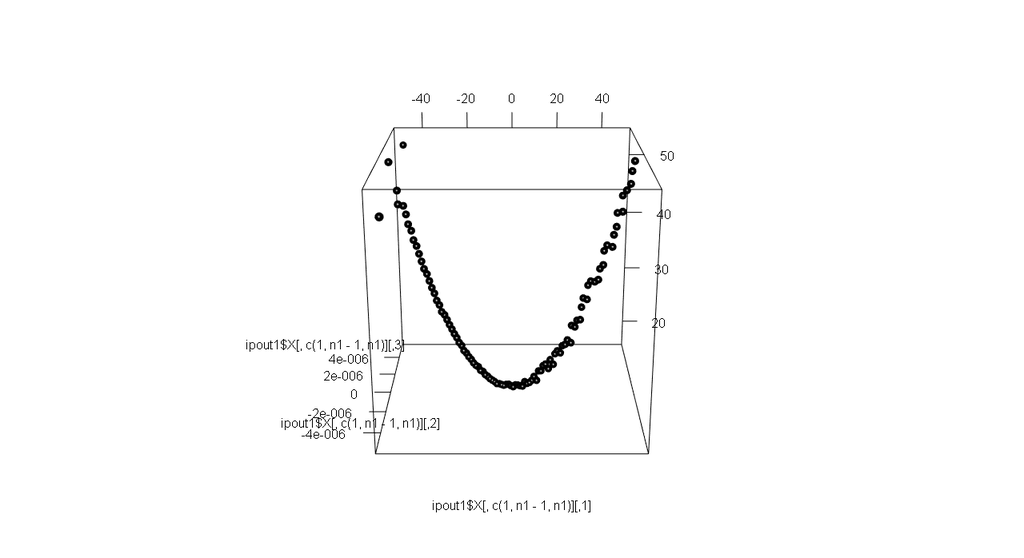

```r
plot3d(ipout1$X[,c(1,n1-1,n1)])
spheres3d(ipout1$X[,c(1,n1-1,n1)],radius=1)
```

## エッジ長がばらばら

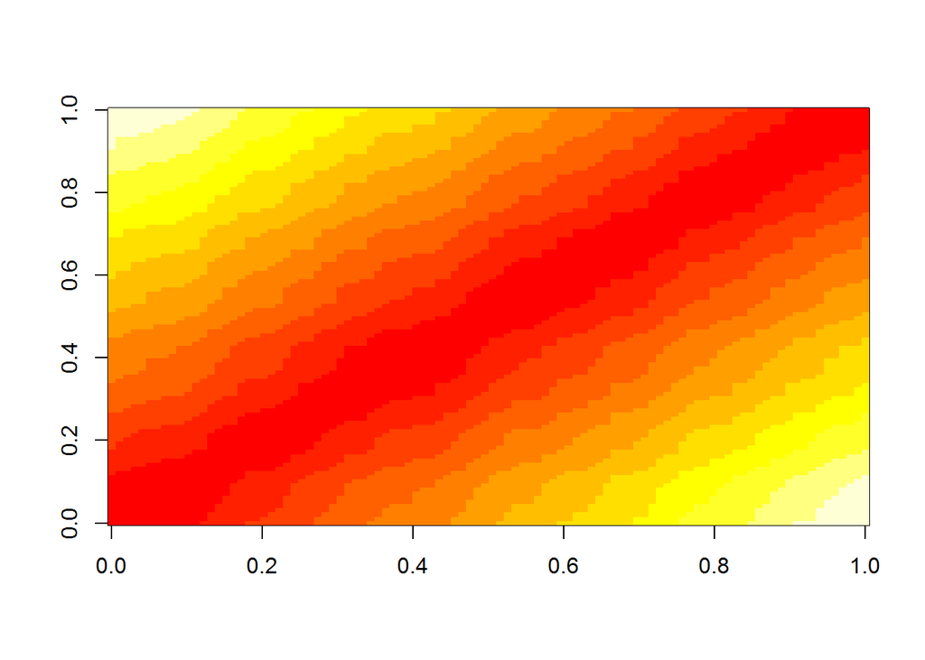

```r
# 1次元グラフ
library(igraph)
# 頂点数
n2 <- 100
el2 <- cbind(1:(n2-1),2:n2)
# グラフオブジェクト
g2 <- graph.edgelist(el2,directed=FALSE)
# エッジ長をばらばらにする
e.len2 <- runif(length(el2[,1]))

ipout2 <- my.IPcoords(g2,e.len2)
# 距離行列
image(ipout2$D)
```

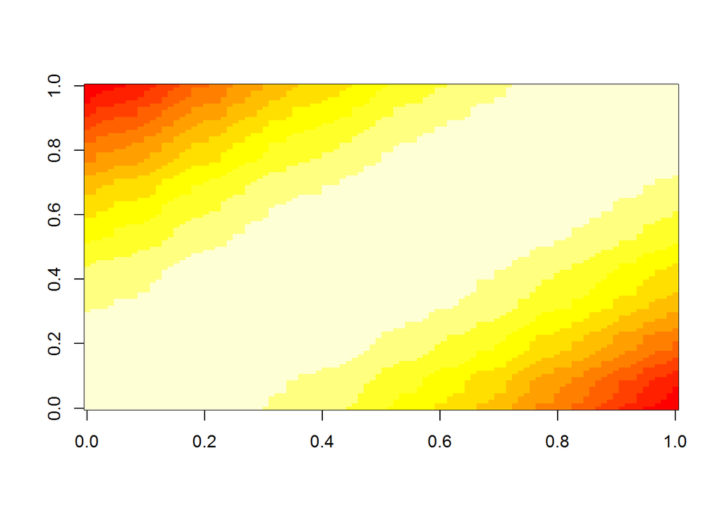

```r
# IP行列
image(ipout2$P)
```

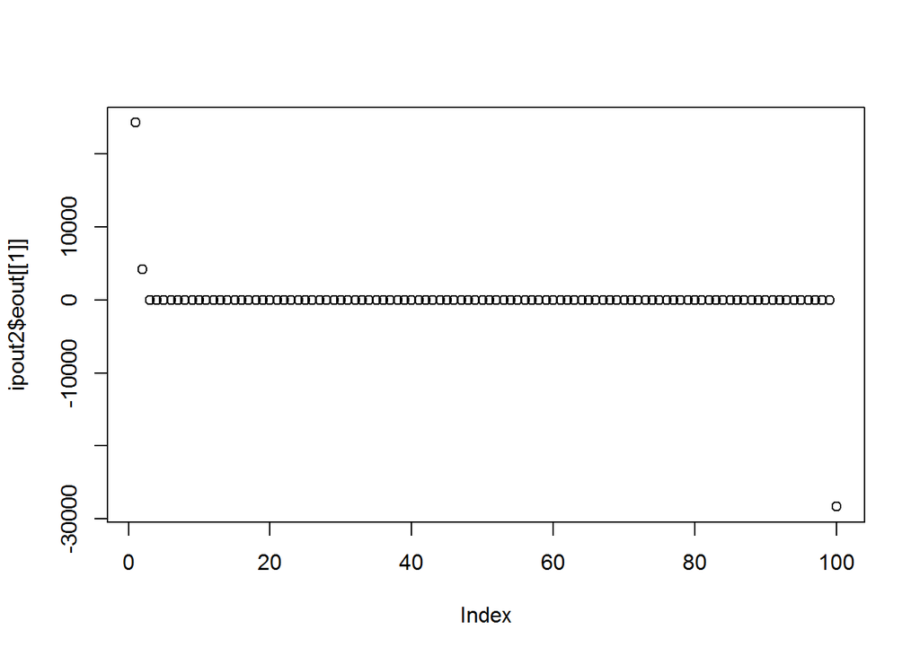

```r
# 固有値
plot(ipout2$eout[[1]])
```

現れるカーブは同じだが、打点の間隔が異なっている。

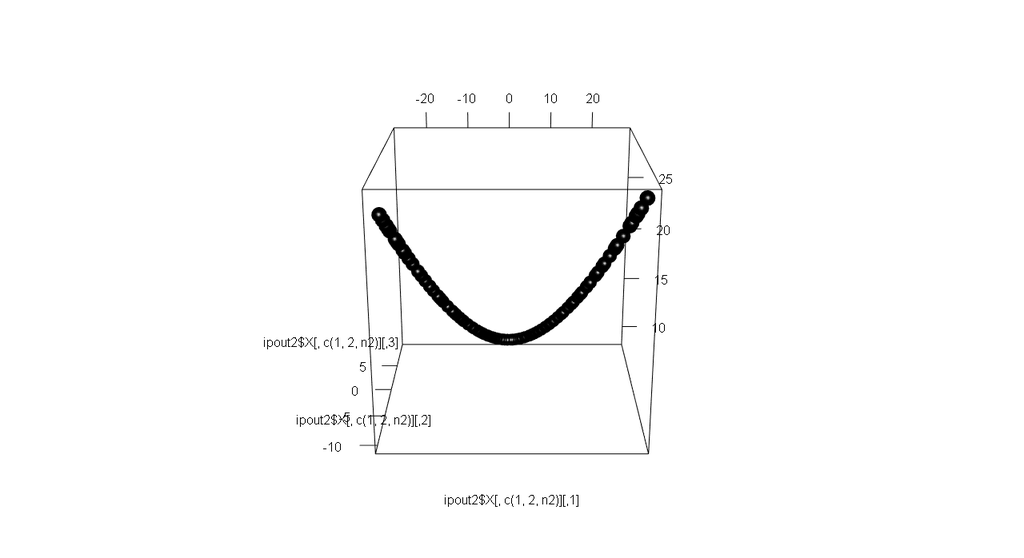

```r
plot3d(ipout2$X[,c(1,2,n2)])
spheres3d(ipout2$X[,c(1,2,n2)],radius=1)
```

## エッジ長がすべて等しい単純な周回グラフ

グラフを作り、エッジ長を与え、 頂点間距離行列を作成し、 内積行列を作る。

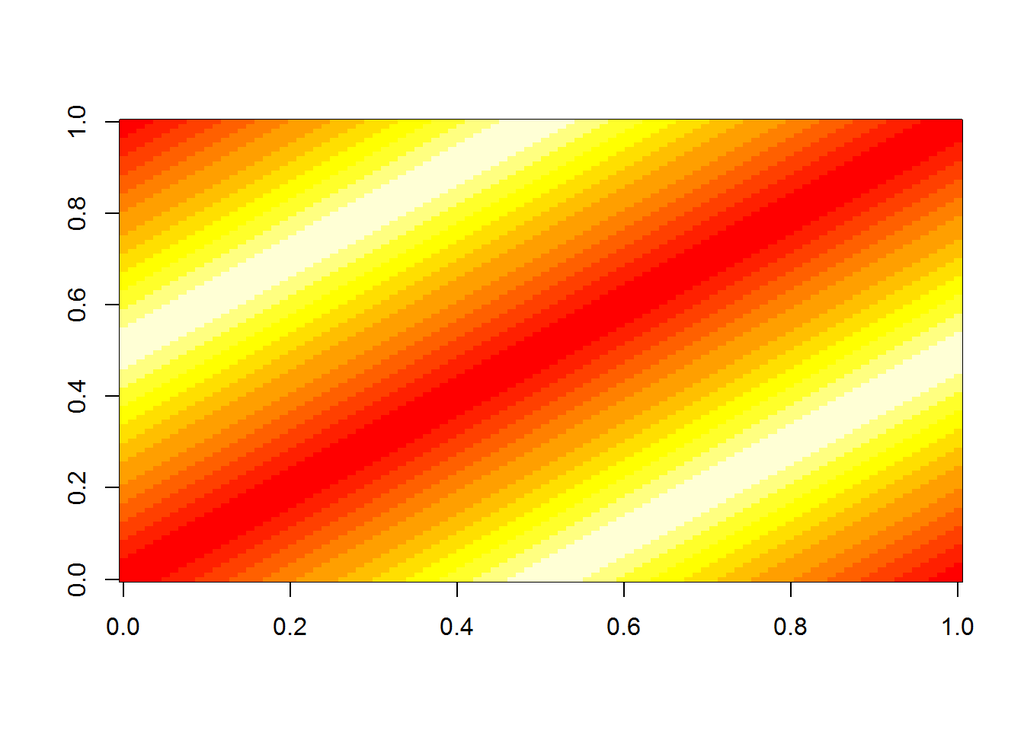

```r
# 円周グラフ
# 頂点数
n3 <- 100
el3 <- cbind(1:(n3-1),2:n3)
el3 <- rbind(el3,c(n3,1))
# グラフオブジェクト
g3 <- graph.edgelist(el3,directed=FALSE)
# エッジ長
e.len3 <- rep(1,length(el3[,1]))
ipout3 <- my.IPcoords(g3,e.len3)
# 距離行列
image(ipout3$D)
```

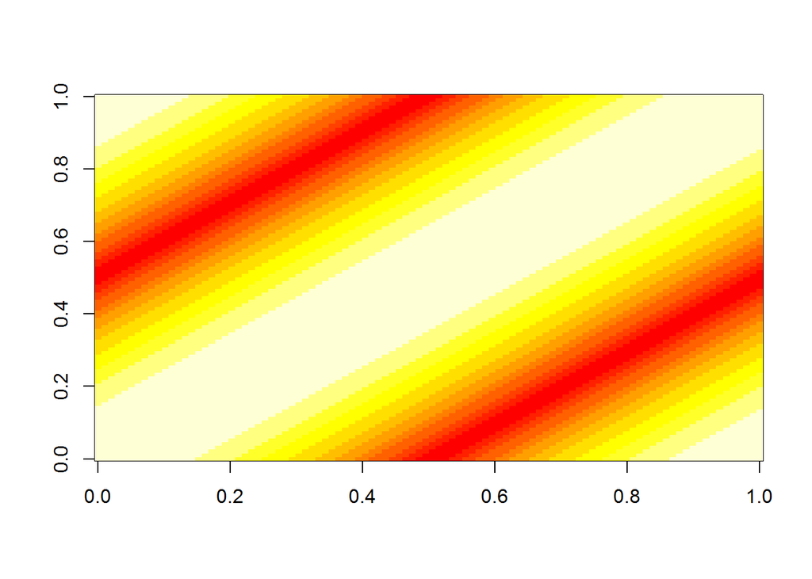

```r
# IP行列
image(ipout3$P)
```

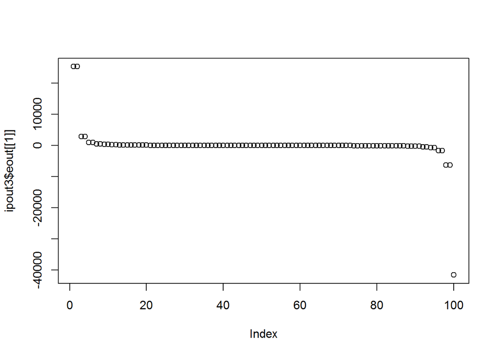

```r
# 固有値
plot(ipout3$eout[[1]])
```

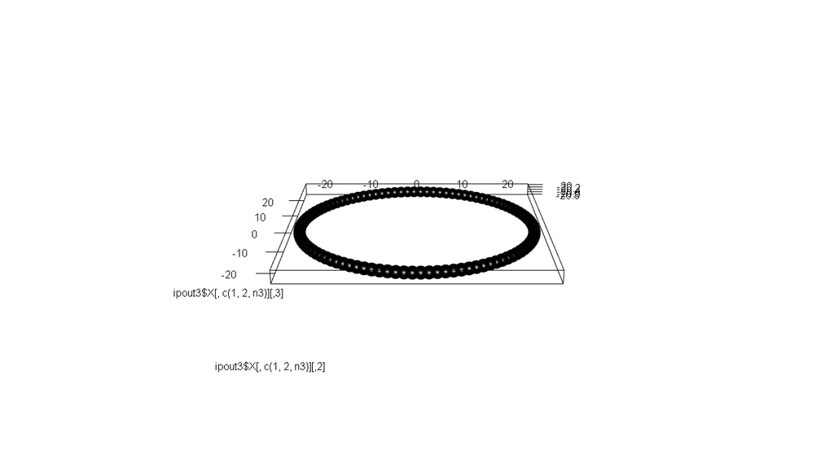

```r
plot3d(ipout3$X[,c(1,2,n3)])
spheres3d(ipout3$X[,c(1,2,n3)],radius=1)
```

## エッジ長をバラバラにする

エッジのばらばら加減が座標に反映する

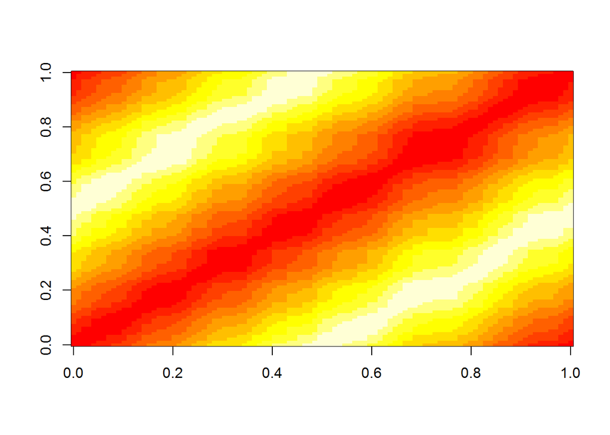

```r
# 円周グラフ
# 頂点数
n4 <- 100
el4 <- cbind(1:(n4-1),2:n4)
el4 <- rbind(el4,c(n4,1))
# グラフオブジェクト
g4 <- graph.edgelist(el4,directed=FALSE)
# エッジ長
e.len4 <- runif(length(el4[,1]))
ipout4 <- my.IPcoords(g4,e.len4)
# 距離行列
image(ipout4$D)
```

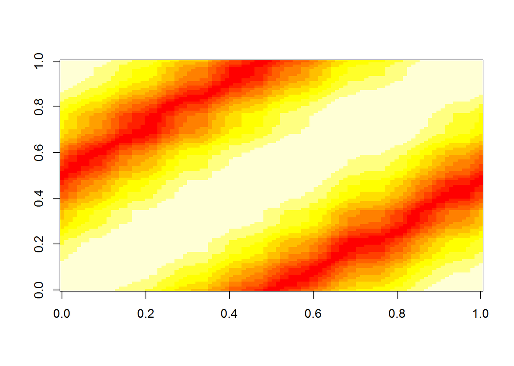

```r
# IP行列
image(ipout4$P)
```

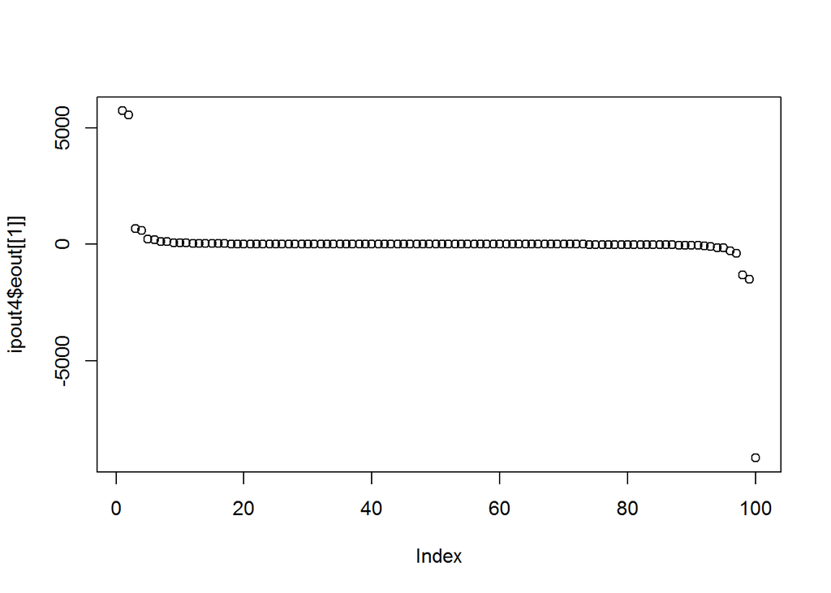

```r
# 固有値
plot(ipout4$eout[[1]])
```

打点間隔がばらつくとともに、実現空間の次元も上がっている。

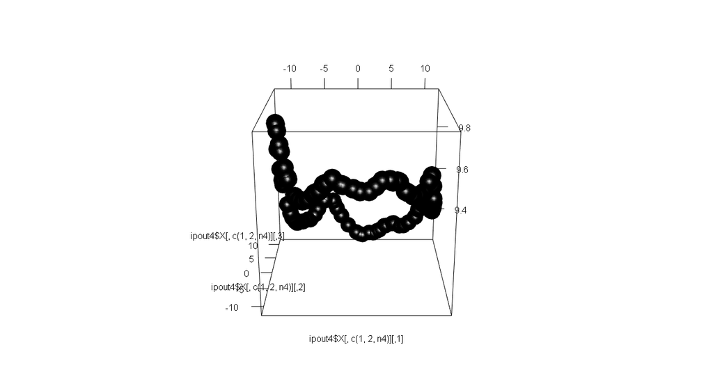

```r
plot3d(ipout4$X[,c(1,2,n4)])
spheres3d(ipout4$X[,c(1,2,n4)],radius=1)
el4 <- get.edgelist(g4)
segments3d(ipout4$X[t(el4),c(1,2,n4)])
```

# 2次元

## 平面方眼紙グラフの場合

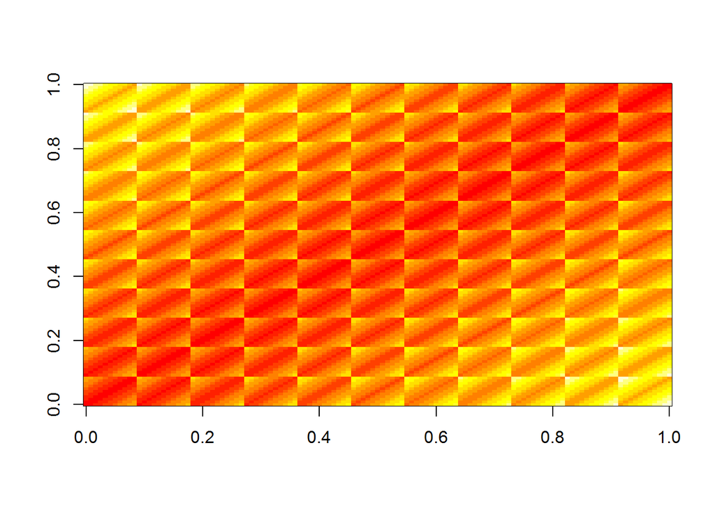

```r
xy <- as.matrix(expand.grid(0:10,0:10))
d <- as.matrix(dist(xy))
d <- d==1 +0
g22 <- graph.adjacency(d,mode="undirected")
# エッジ長
e.len22 <- rep(1,length(E(g22)))
ipout22 <- my.IPcoords(g22,e.len22)
# 距離行列
image(ipout22$D)
```

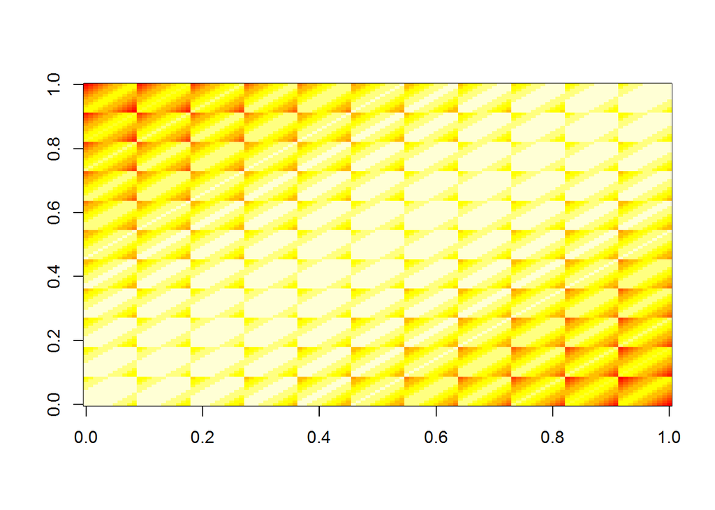

```r
# IP行列
image(ipout22$P)
```

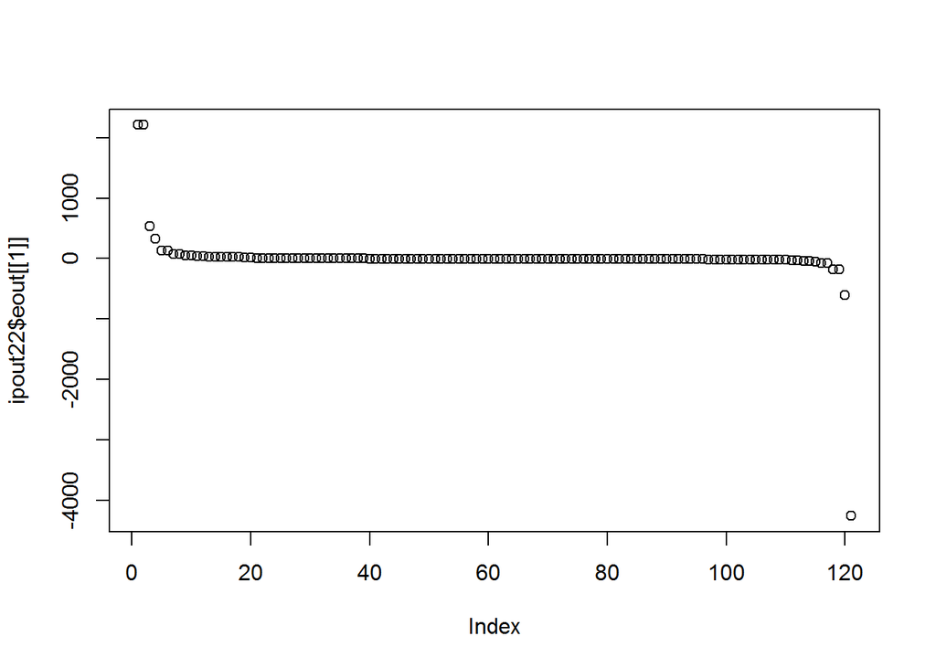

```r
# 固有値
plot(ipout22$eout[[1]])
```

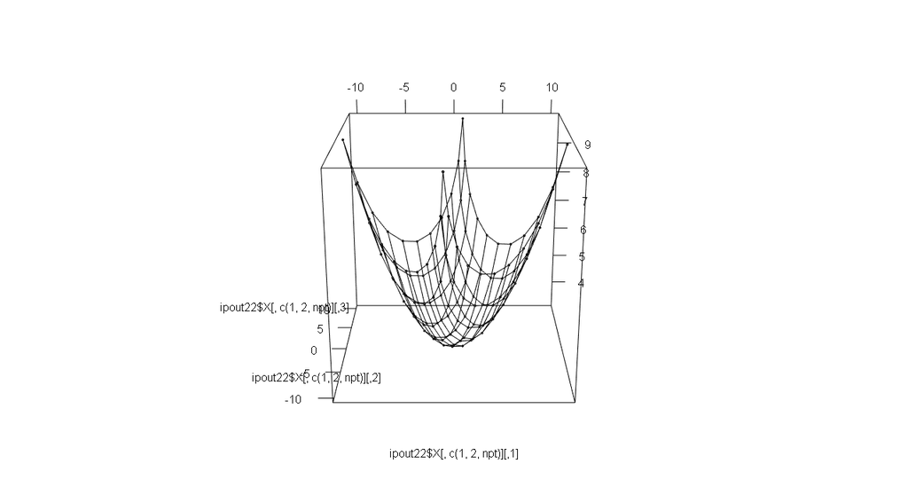

```r
npt <- length(xy[,1])
plot3d(ipout22$X[,c(1,2,npt)])
spheres3d(ipout22$X[,c(1,2,npt)],radius=0.1)
el22 <- matrix(as.numeric(get.edgelist(g22)),ncol=2)
segments3d(ipout22$X[t(el22),c(1,2,npt)])
```

ばらつかせる。

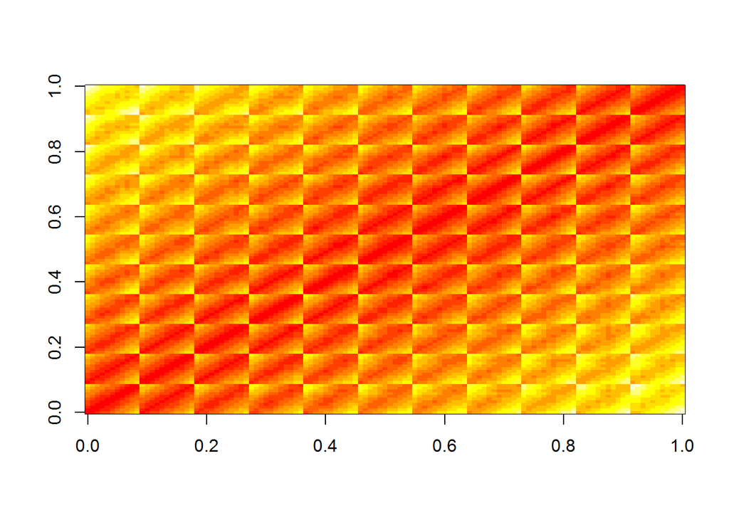

```r
xy <- as.matrix(expand.grid(0:10,0:10))
d <- as.matrix(dist(xy))
d <- d==1 +0
g22 <- graph.adjacency(d,mode="undirected")
# エッジ長
e.len22 <- rep(1,length(E(g22))) + runif(length(E(g22)))
ipout22 <- my.IPcoords(g22,e.len22)
# 距離行列
image(ipout22$D)
```

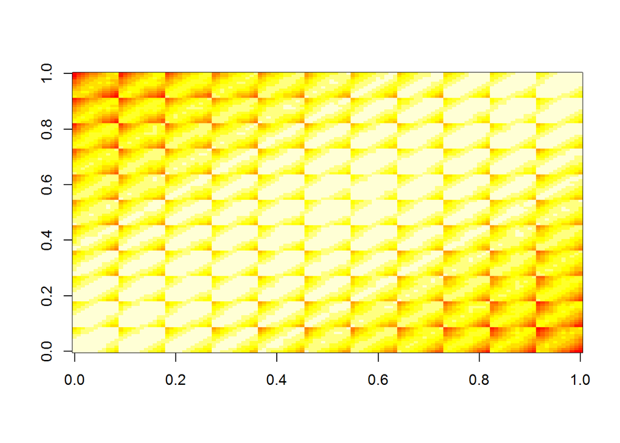

```r
# IP行列
image(ipout22$P)
```

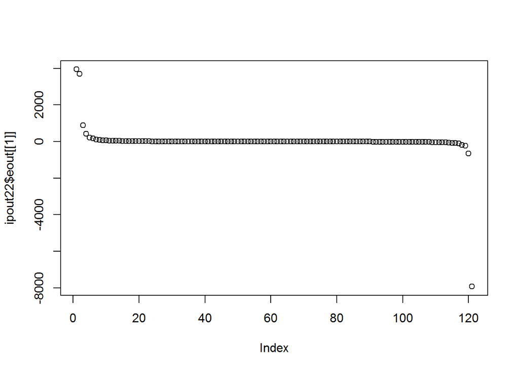

```r
# 固有値
plot(ipout22$eout[[1]])
```

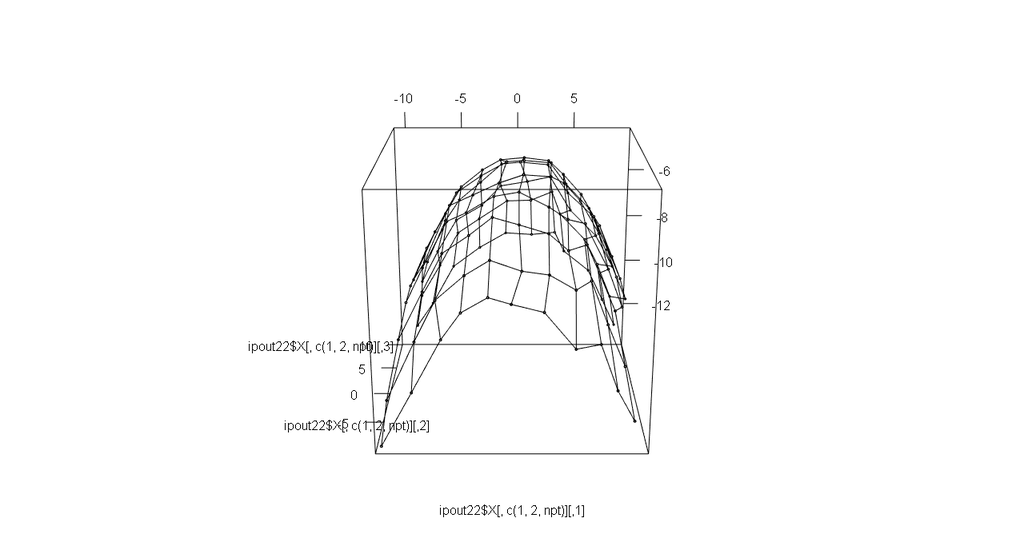

```r
npt <- length(xy[,1])
plot3d(ipout22$X[,c(1,2,npt)])
spheres3d(ipout22$X[,c(1,2,npt)],radius=0.1)
el22 <- matrix(as.numeric(get.edgelist(g22)),ncol=2)
segments3d(ipout22$X[t(el22),c(1,2,npt)])
```

```r
newip <- ipout22$X %*% ipout22$M %*% t(ipout22$X)
nn <- length(newip[,1])
newdsq <- matrix(0,nn,nn)
for(i in 1:nn){
  for(j in 1:nn){
    newdsq[i,j] <- newip[i,i] + newip[j,j] - 2*newip[i,j]
  }
}
range(newdsq - ipout22$D^2)
```

```
## [1] -4.718004e-12  7.275958e-12
```

```r
#newip - ipout22$P
```

## 閉曲面メッシュグラフを作ってやってみる。

それなりのメッシュグラフを作る

```r
library(devtools)
# install_github("ryamada22/Ronlyryamada") 初回はインストールする
library(Ronlyryamada)
library(RFOC)

n <- 5 # メッシュの複雑さを指定(大きいと凹凸の周期が細かくなる)
k <- 2 # メッシュの複雑さを指定(大きいと真球に近くなる)
n.mesh <- 32 # メッシュの細かさを指定
A. <- matrix(runif(n^2), n, n)
A.[1, 1] <- k
A. <- A. + rnorm(n^2, 0, 0.05)
xxx <- my.spherical.harm.mesh(A = A., n = n.mesh)
```

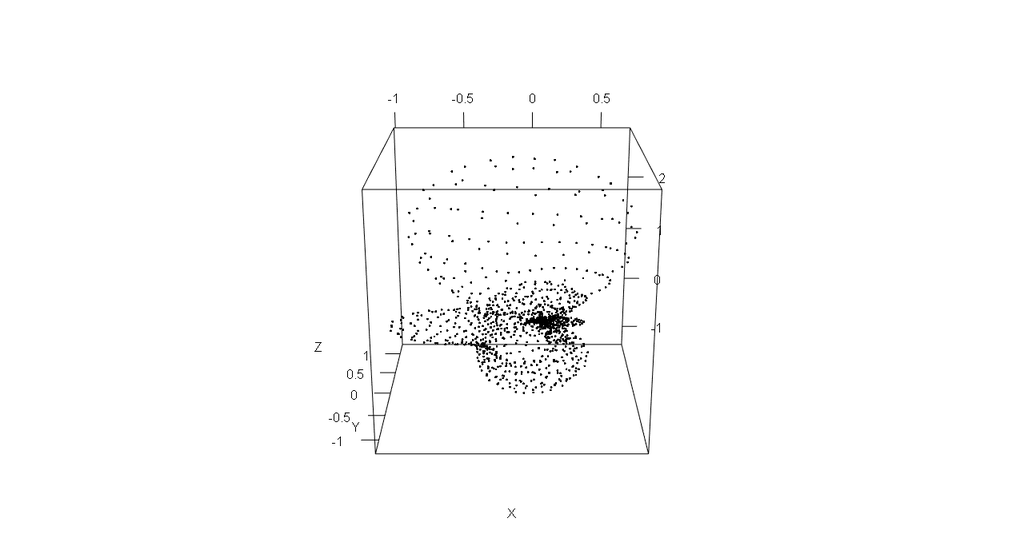

```r
X <- xxx[[1]]
plot3d(X)
```

```r
g5 <- graph.edgelist(xxx$edge,directed=FALSE)
#plot(g)

e.len5 <- rep(0,length(xxx$edge[,1]))
for(i in 1:length(e.len5)){
    e.len5[i] <- sqrt(sum((X[xxx$edge[i,1],]-X[xxx$edge[i,2],])^2))
}
```

```r
ipout5 <- my.IPcoords(g5,e.len5)
```

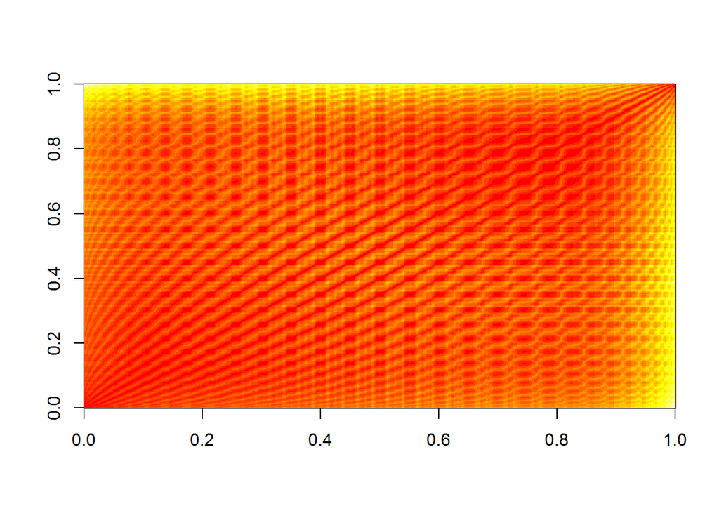

```r
# 距離行列
image(ipout5$D)
```

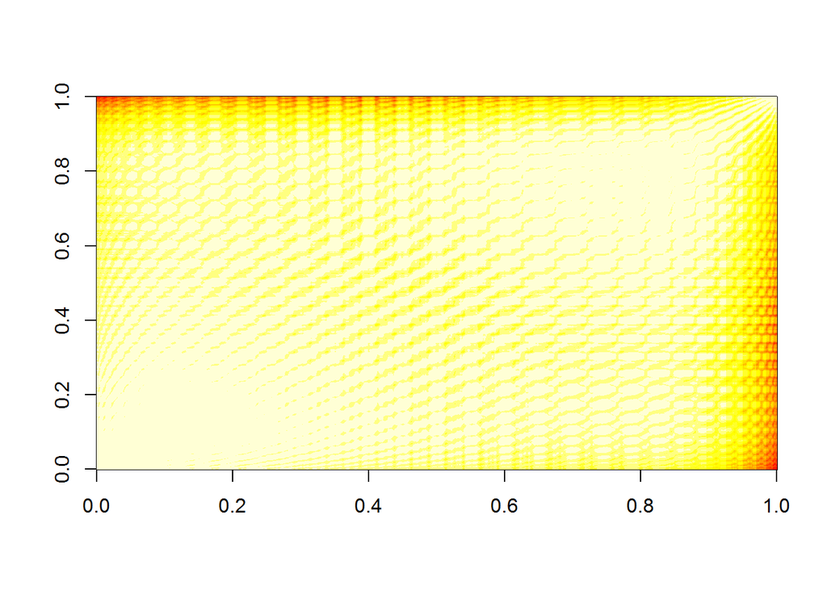

```r
# IP行列
image(ipout5$P)
```

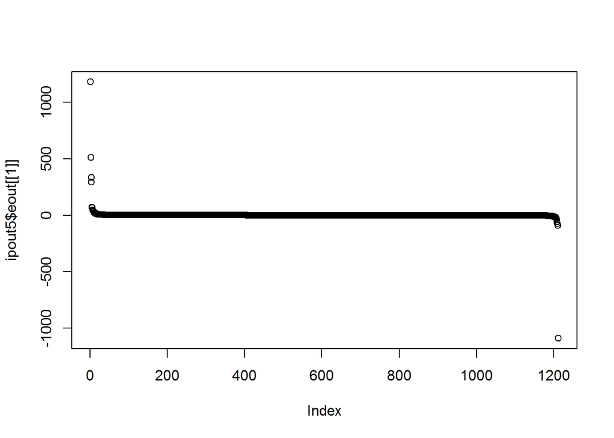

```r
# 固有値
plot(ipout5$eout[[1]])
```

次の3dプロットは、一部の意味のある固有値成分しか使っていないことに注意。

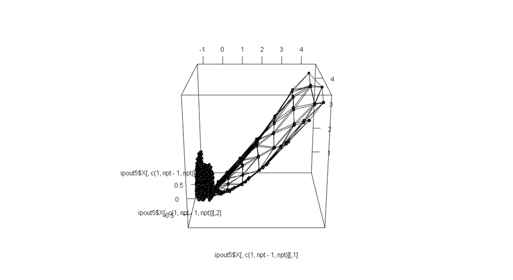

```r
npt <- length(ipout5$eout[[1]])
plot3d(ipout5$X[,c(1,npt-1,npt)])
spheres3d(ipout5$X[,c(1,npt-1,npt)],radius=0.05)


el5 <- get.edgelist(g5)
segments3d(ipout5$X[t(el5),c(1,npt-1,npt)])
```

内積行列Mで表されている空間での点がばらつくということは、負寄与方向の座標を使って、 局所の長さの測り方(内積・曲率の指標)が異なることを示していることになる。

したがって、今、行っている方法では、 現実空間での形は同じでも、そこへのメッシュの張り方を変えると、内積行列Mの空間での表現が変わることになる。 言い換えると、現実空間での点の取り方は等距離で取るのが良いのでは…。